# Transaction Cost of Munis for Retail Clients

atul.patel@PrincetonPointCapital.com

12/15/2017

### Municipal Bond Market

Municipal bonds have long been considered difficult to trade for a variety of reasons:

- The market of bonds is broad, with over 60,000 issuers and approximately 1 million outstanding bonds.[^1]
- The market is relatively shallow, with only $3 trillion municipal bonds versus $20 trillion treasury bonds.[^2]
- Ownership is skewed, with over 50% of the bonds owned by retail investors. However less than 3% of all households own municipal bonds. Of that group, only about 1% of them buy bonds direct.[^3]

In short, the municipal bond market has a large number issuers, who issue relatively little debt, which is bought by a small subset of U.S. retail investors. Given this backdrop it is understandable that municipal bonds are not broadly covered in business media and that trade information is not readily available. Though the municipal governing board has done much to increase transparency, municipal retail investors have a disadvantage with regards to information.

This information gap creates the environment in which spreads could be relatively wide. In this report we try to quantify this spread using daily trade data captured over a 1 year period starting Oct 2016 to current.[^4]

#### Average Daily Max Spread

What do we mean by average daily max spread? We captured the trading activity of the 100 most active municipal bonds each day as reported by the Municipal Securities Rulemaking Board (MSRB). This basket of 100 bonds is not static, but instead changes every day based on reported trades. From this basket of bonds, we want to calculate the winners and losers of the day. The winners are those who paid the least and the losers are those who paid the most, for the same bond on the same day. Average Daily Max Spread is the average price difference between the winners and losers of all the individual bonds in our basket.

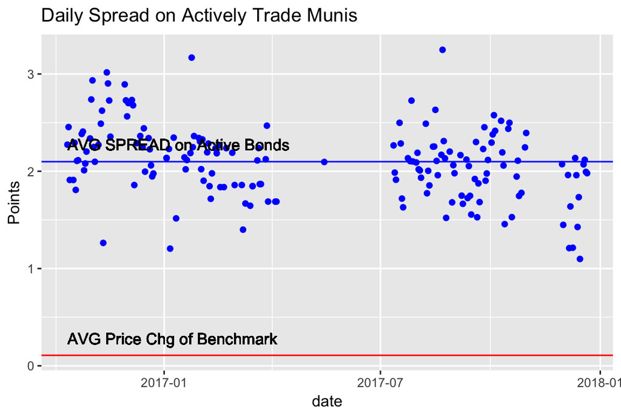

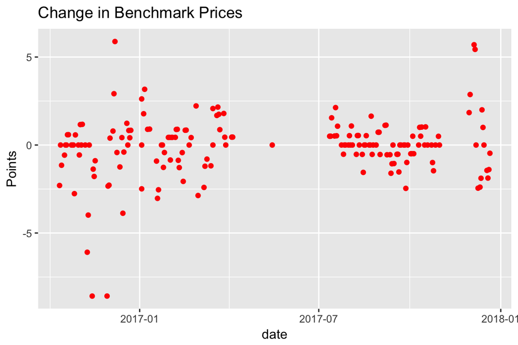

If the broker is not able to quickly find a buyer, they are exposed to multiple days of interest rate risk, which may trend against them. There are ways a broker can mitigate these losses as a part of a risk management strategy. It is also worth noting in the graph above that large price drops are usually followed by similar magnitude reversals. Hence a broker is capable of capturing the lion share of the bid-ask.

#### Average Spread on Individual Bond

Now let’s take a look at an individual bond example over our time period. Here are some the most active issuers since Oct 2016.

```
## # A tibble: 10 x 2
##                                                                       emmaDesc
##                                                                          <chr>
##  1    STATE OF CALIFORNIA / VARIOUS PURPOSE GENERAL OBLIGATION REFUNDING BONDS
##  2 "COMMONWEALTH OF PUERTO RICO / PUBLIC IMPROVEMENT REFUNDING BONDS, SERIES 2
##  3 MICHIGAN FINANCE AUTHORITY HOSPITAL / REVENUE REFUNDING BONDS (HENRY FORD H
##  4 STATE OF OHIO / HOSPITAL REFUNDING REVENUE BONDS,  SERIES 2017A  (CLEVELAND
##  5 BAY AREA TOLL AUTHORITY / SAN FRANCISCO BAY AREA SUBORDINATE TOLL BRIDGE RE
##  6 STATE OF NEW JERSEY / NEW JERSEY GENERAL OBLIGATION BONDS (VARIOUS PURPOSES
##  7 COMMONWEALTH OF PENNSYLVANIA, PENNSYLVANIA / GENERAL OBLIGATION BONDS, SECO
##  8 NEW YORK CITY MUNICIPAL WATER FINANCE AUTHORITY, NEW YORK / WATER AND SEWER
##  9 SCHOOL DISTRICT NO. 1J, MULTNOMAH COUNTY, OREGON (PORTLAND PUBLIC SCHOOLS)
## 10              STATE OF CALIFORNIA / VARIOUS PURPOSE GENERAL OBLIGATION BONDS
## # ... with 1 more variables: n <int>
```

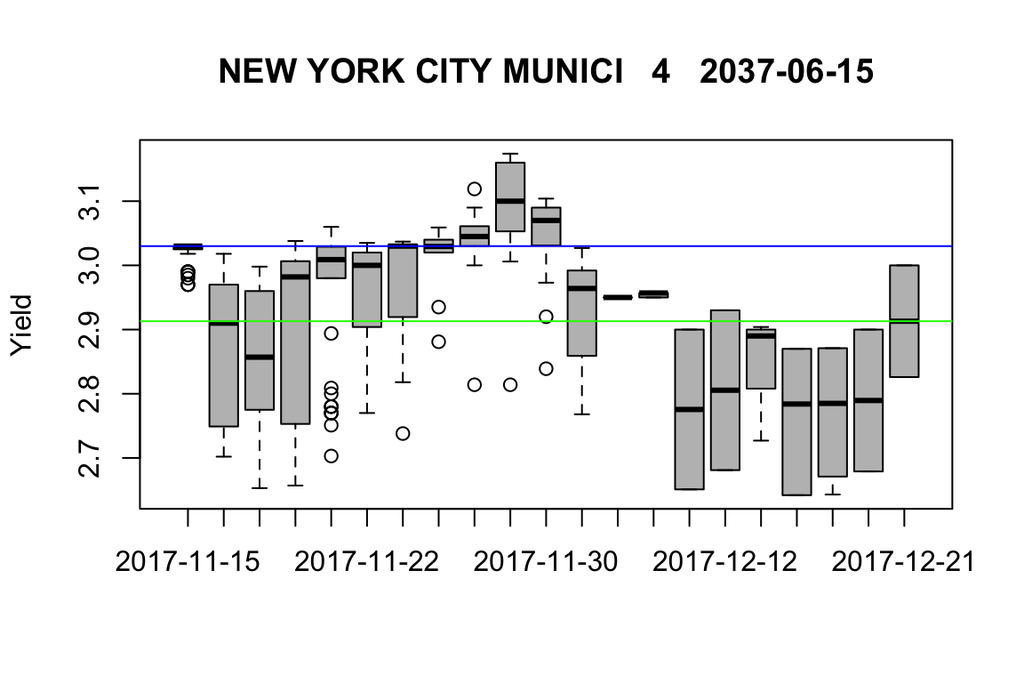

We have a statistically significant amount of trade data here to make appropriate inferences. Bonds issued by New York entities have good retail participation, hence we will get a good cross section of the both institutional and retail trades. For our case, I am going to define trades of 1mm and higher as institutional, and the inverse as retail trades.

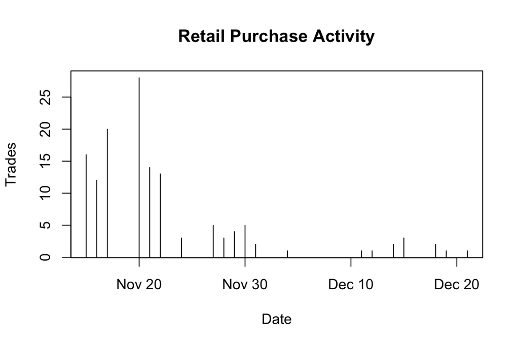

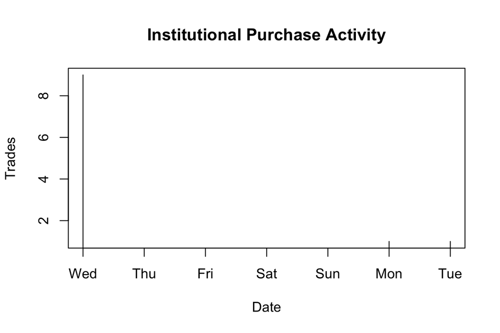

As you can see there is a lot more trade activity in this bond in retail size. For reason we won’t go into here, this isn’t the ideal bond structure for institutional investors. So why is it popular with retail accounts? It might have something to do with the options retail brokers show their clients.

With the NYC Water bond price history, we look at the trade data in more detail. We query the data to see when retail clients have transacted as both buyers and sellers on the same day. By definition of being an intermediary, it is the price a broker bought and sold on that day. For our purpose we are taking the average price of all the broker buys and sells to get our approximation of the bid-ask spread a retail client pays.

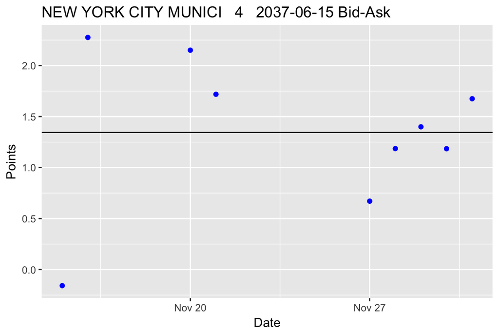

Remember we picked what is considered a new and relatively liquid municipal bond. There are many more smaller and less liquid bonds in which the spreads may rightfully be even wider.

Given that there is no national exchange where all bids and offers must be transmitted, investors rely on brokers for price discovery. From our analysis, it is likely that retail clients can see bid-ask spread in excess of 2 points when tapping their brokers for liquidity. Given that current yield for a AAA municipal is around 2%, is equivalent to 1 year worth of interest. There are not many ways retail clients can reduce this bid-ask spread if they need to tap their broker for liquidity when selling a bond. However when buying a bond, retail has the option of buying bonds in the new issue where:

- The issuer of the bond pays the spread.
- All investors pay the same price for the same bond.
- Sometimes investors get a discounted price for large new issue deals.

#### Summary

The truth is whether buying munis or stocks, your long-term returns are generally better when you minimize the cost of trading. It is our intent here to educate existing and potential municipal investors of the cost when buying and selling a municipal bond.